# Reproducible Research: Peer Assessment 1

Jungmun Lee

26/04/2020

## Loading and preprocessing the data

```r
data <- read.csv("./activity.csv")
```

## What is mean total number of steps taken per day?

```r
daily_steps <- aggregate(steps ~ date, data, sum)
```

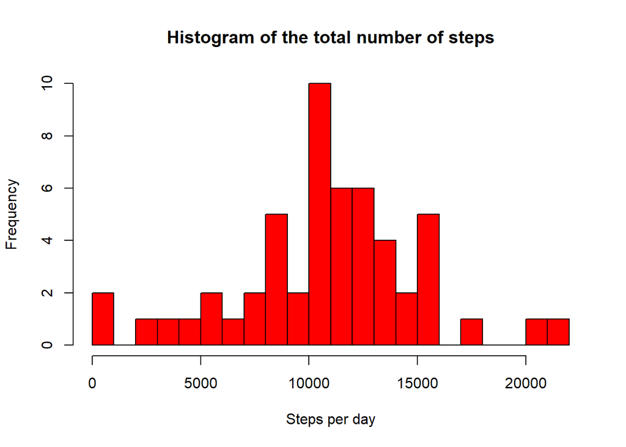

```r
hist(daily_steps$steps, breaks=20, col="red",
    xlab="Steps per day",
    main="Histogram of the total number of steps")
```

# Calculate and report the mean and median of the total number of steps taken per day

```r
mean(daily_steps$steps)
```

```
## [1] 10766.19
```

```r
median(daily_steps$steps)
```

```
## [1] 10765
```

## What is the average daily activity pattern?

```r
interval_steps <- aggregate(steps ~ interval, data, mean)
```

Time series plot of the 5-minute interval (x-axis) and the average number of steps taken, averaged across all days (y-axis)

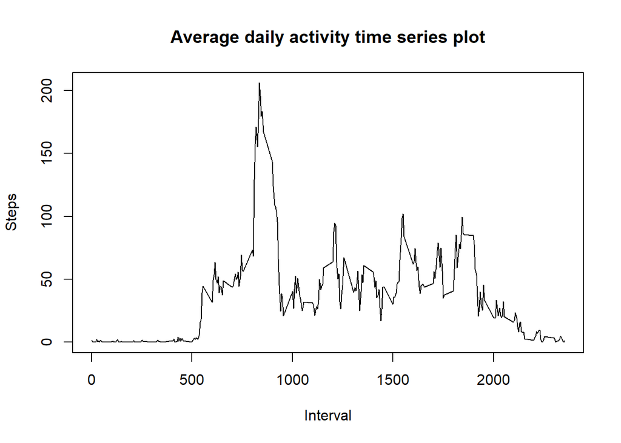

```r
plot(interval_steps$interval, interval_steps$steps, type = "l",
     xlab = "Interval", ylab = "Steps",
     main = "Average daily activity time series plot")
```

Which 5-minute interval, on average across all the days in the dataset, contains the maximum number of steps?

```r
interval_steps[which.max(interval_steps$steps),]
```

```
##     interval    steps
## 104      835 206.1698
```

## Imputing missing values

Calculate and report the total number of missing values in the dataset

```r
sum(is.na(data))
```

```
## [1] 2304
```

Misssing values will be replace with the mean for that 5-minute interval.

```r
na_data <- is.na(data$steps)
avg_interval <- tapply(data$steps, data$interval, mean, na.rm=TRUE)
data$steps[na_data] <- avg_interval[as.character(data$interval[na_data])]
```

Result after imputing missing values

```r
sum(is.na(data))
```

```
## [1] 0
```

Create a new dataset that is equal to the original dataset but with the missing data filled in.

```r
daily_steps <- aggregate(steps ~ date, data, sum)
```

Make a histogram of the total number of steps taken each day and Calculate and report the mean and median total number of steps taken per day.

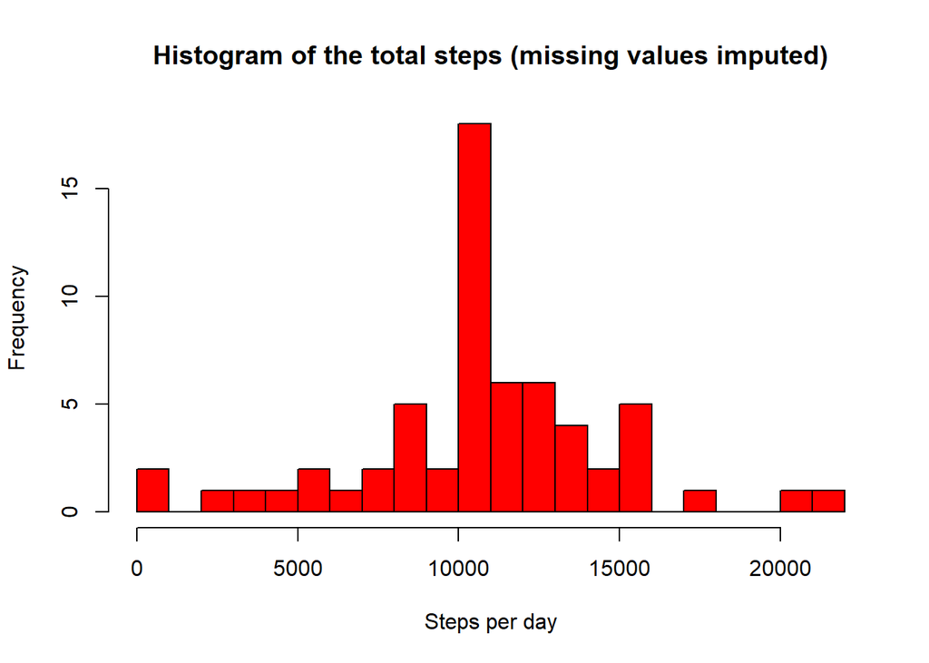

```r
hist(daily_steps$steps, breaks=20, col="red",
     xlab="Steps per day",
     main="Histogram of the total steps (missing values imputed)")
```

```r
mean(daily_steps$steps)
```

```
## [1] 10766.19
```

```r
median(daily_steps$steps)
```

```
## [1] 10766.19
```

After imputing missing data the mean and the median of the total daily number of steps are the same.

## Are there differences in activity patterns between weekdays and weekends?

Create a new factor variable in the dataset with two levels – “weekday” and “weekend” indicating whether a given date is a weekday or weekend day.

```r
data$daytype <- rep(NA, nrow(data))
data$daytype <- strftime(data$date, "%A")
data[data$daytype %in% c("Monday","Tuesday","Wednesday","Thursday","Friday"),]$daytype <- "Weekday"
data[data$daytype %in% c("Saturday","Sunday"),]$daytype <- "Weekend"
```

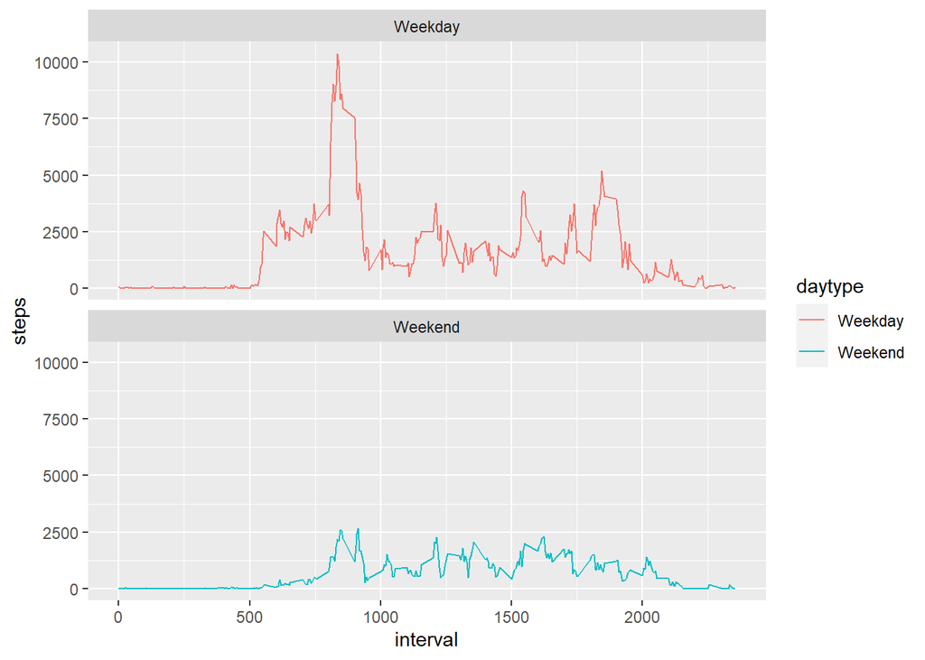

```r
daytype_steps <- aggregate(steps ~ interval + daytype, data, sum)

library(ggplot2)
ggplot(daytype_steps, aes(x=interval, y=steps, color=daytype)) +
  geom_line() +
  facet_wrap(~daytype, ncol=1, nrow=2)
```